# Co-Occurrence Matrix

##### Co-Occurrence Matrix

- Create Co-occurrence Matrix Embedding:
  - Tokenize the sentence and build a co-occurrence matrix.
  - Then, we'll use Singular Value Decomposition (SVD) to create an embedding from the co-occurrence matrix.
    - Co-occurrence Matrix: The function create_cooccurrence_matrix computes the co-occurrence matrix for a given sentence. Each word in the sentence is mapped to an index, and the matrix is populated by counting co-occurrences of consecutive words.
- Store Embedded Data in FAISS:
  - SVD Embedding: The embed_using_svd function reduces the dimensionality of the co-occurrence matrix using Singular Value Decomposition (SVD), which results in a dense vector representation for each word.
  - Use FAISS to store and retrieve the embedding vectors efficiently.
    - FAISS Indexing: The store_in_faiss function stores the embeddings in FAISS, an efficient library for vector similarity search. The vectors are normalized before being added to the FAISS index.
- Display Nearest Neighbors:
  - After storing the embeddings in FAISS, we'll retrieve the nearest neighbors and display them graphically.
    - Nearest Neighbors: The retrieve_nearest_neighbours function searches for the nearest neighbors of a given query vector (in this case, the first word embedding).
- Display the Embedding Data in Tabular Form:
  - Display the index, the embedding vector, and the associated word data in a tabular format.
    - Tabular Representation: The display_embedding_table function shows the embeddings in a pandas DataFrame format, where each row corresponds to a word and its embedding vector.
- Generate a Co-occurrence Matrix Heatmap:
  - Visualize the co-occurrence matrix as a heatmap.
    - Co-occurrence Matrix Heatmap: The plot_cooccurrence_heatmap function visualizes the co-occurrence matrix as a heatmap using seaborn.
- Main Function: The main function ties everything together: it creates the co-occurrence matrix, embeds the data, stores it in FAISS, and displays the results.

```python
%pip install -q numpy pandas faiss-cpu scikit-learn matplotlib seaborn
```

[output not shown]

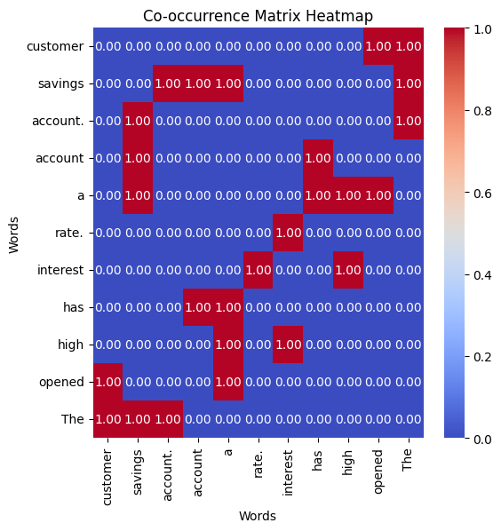

|  | Embedding 1 | Embedding 2 |
| --- | --- | --- |
| customer | 0.624027 | 0.144949 |
| savings | 1.423712 | -1.162395 |
| account. | 0.901047 | 0.365215 |
| account | 0.772586 | 0.842155 |
| a | 1.194755 | 1.381222 |
| rate. | 0.076639 | -0.139605 |
| interest | 0.211836 | 0.342796 |
| has | 0.711759 | -0.905482 |
| high | 0.508886 | -0.702116 |
| opened | 0.658012 | -0.621541 |
| The | 1.066833 | 0.265625 |

|  | Word | Index | Distance |
| --- | --- | --- | --- |
| Word 1 Neighbours | customer | 0 | 0.129140 |
| Word 1 Neighbours | The | 10 | 0.129299 |
| Word 1 Neighbours | account. | 2 | 0.144869 |
| Word 1 Neighbours | account | 3 | 0.353094 |
| Word 1 Neighbours | a | 4 | 0.374677 |
| Word 2 Neighbours | savings | 1 | 0.702188 |
| Word 2 Neighbours | opened | 9 | 0.711767 |
| Word 2 Neighbours | has | 7 | 0.790725 |
| Word 2 Neighbours | high | 8 | 0.824729 |
| Word 2 Neighbours | rate. | 5 | 0.969961 |

```python
import numpy as np
import pandas as pd
import matplotlib.pyplot as plt
import seaborn as sns
from sklearn.decomposition import TruncatedSVD
import faiss

# Step 1: Create Co-occurrence Matrix Embedding
def create_cooccurrence_matrix(sentence):
    words = sentence.split()
    word_to_idx = {word: idx for idx, word in enumerate(set(words))}
    co_matrix = np.zeros((len(word_to_idx), len(word_to_idx)))

    # Fill the co-occurrence matrix
    for i, word in enumerate(words[:-1]):
        word_idx = word_to_idx[word]
        next_word_idx = word_to_idx[words[i + 1]]
        co_matrix[word_idx, next_word_idx] += 1
        co_matrix[next_word_idx, word_idx] += 1  # Undirected graph

    return co_matrix, word_to_idx

# Step 2: Embed using SVD (Co-occurrence Matrix Embedding)
def embed_using_svd(co_matrix, n_components=2):
    svd = TruncatedSVD(n_components=n_components)
    return svd.fit_transform(co_matrix)

# Step 3: Store in FAISS
def store_in_faiss(embeddings):
    embeddings = embeddings.astype(np.float32)  # Ensure embeddings are float32
    dim = embeddings.shape[1]
    index = faiss.IndexFlatL2(dim)  # L2 distance metric
    faiss.normalize_L2(embeddings)  # Normalize vectors to unit length
    index.add(embeddings)
    return index

# Step 4: Retrieve Nearest Neighbour
def retrieve_nearest_neighbours(index, query_vector, k=5):
    D, I = index.search(query_vector.astype(np.float32), k)
    return I, D

# Step 5: Visualizing Co-occurrence Matrix as Heatmap
def plot_cooccurrence_heatmap(co_matrix, word_to_idx):
    plt.figure(figsize=(6, 6))
    sns.heatmap(co_matrix, annot=True, fmt='.2f', cmap='coolwarm',
                xticklabels=word_to_idx.keys(), yticklabels=word_to_idx.keys())
    plt.title('Co-occurrence Matrix Heatmap')
    plt.xlabel('Words')
    plt.ylabel('Words')
    plt.show()

# Step 6: Tabular Representation of Embedding Data with Borders
def display_embedding_table(embeddings, word_to_idx):
    word_list = list(word_to_idx.keys())
    df = pd.DataFrame(embeddings, index=word_list)
    df.columns = [f'Embedding {i+1}' for i in range(embeddings.shape[1])]

    # Apply styling to add borders and improve readability
    styled_df = df.style.set_table_styles(
        [{'selector': 'thead th', 'props': [('border', '1px solid black'), ('background-color', '#f2f2f2')]},  # header style
         {'selector': 'tbody td', 'props': [('border', '1px solid black')]},  # cell border
         {'selector': 'table', 'props': [('border-collapse', 'collapse'), ('width', '100%')]},  # table styles
         {'selector': 'thead', 'props': [('text-align', 'center')]},  # center align header
         {'selector': 'tbody', 'props': [('text-align', 'center')]},  # center align body
        ])
    display(styled_df)

# Step 7: Display Nearest Neighbors in a Structured Table
def display_nearest_neighbors(word_to_idx, embeddings, index, words_to_check=[0, 1], k=5):
    # Create a table for nearest neighbors
    neighbors_data = []

    for word_idx in words_to_check:
        query_vector = embeddings[word_idx].reshape(1, -1)
        neighbors_idx, neighbors_dist = retrieve_nearest_neighbours(index, query_vector, k)
        neighbors_info = []

        for i, idx in enumerate(neighbors_idx[0]):
            neighbors_info.append({
                'Word': list(word_to_idx.keys())[idx],
                'Index': idx,
                'Distance': neighbors_dist[0][i]
            })
        neighbors_data.append(neighbors_info)

    # Convert neighbors data to pandas DataFrame for better display
    neighbors_df = pd.DataFrame(neighbors_data[0]) if neighbors_data else pd.DataFrame()
    neighbors_df.index = ['Word 1 Neighbours'] * len(neighbors_data[0])

    # Concatenate additional neighbors (e.g., for Word 2)
    for i, data in enumerate(neighbors_data[1:], start=2):
        word_neighbors_df = pd.DataFrame(data)
        word_neighbors_df.index = [f'Word {i} Neighbours'] * len(data)
        neighbors_df = pd.concat([neighbors_df, word_neighbors_df])

    # Display the nearest neighbors in tabular format
    styled_neighbors_df = neighbors_df.style.set_table_styles(
        [{'selector': 'thead th', 'props': [('border', '1px solid black'), ('background-color', '#f2f2f2')]},  # header style
         {'selector': 'tbody td', 'props': [('border', '1px solid black')]},  # cell border
         {'selector': 'table', 'props': [('border-collapse', 'collapse'), ('width', '100%')]},  # table styles
         {'selector': 'thead', 'props': [('text-align', 'center')]},  # center align header
         {'selector': 'tbody', 'props': [('text-align', 'center')]},  # center align body
        ])
    display(styled_neighbors_df)

# Step 8: Main function to tie everything together
def main(sentence):
    # Create Co-occurrence Matrix
    co_matrix, word_to_idx = create_cooccurrence_matrix(sentence)

    # Display the Co-occurrence Matrix Heatmap
    plot_cooccurrence_heatmap(co_matrix, word_to_idx)

    # Embed using SVD
    embeddings = embed_using_svd(co_matrix)

    # Store in FAISS
    index = store_in_faiss(embeddings)

    # Display Embedding Data with Borders and Headers
    display_embedding_table(embeddings, word_to_idx)

    # Display nearest neighbors for Word 1 and Word 2
    display_nearest_neighbors(word_to_idx, embeddings, index)

# Example sentence
#sentence = "apple orange banana apple banana fruit orange"
#sentence = """
#The cat sits on the mat.
#The dog lies on the mat.
#The cat and dog are friends.
#"""

sentence = """
The customer opened a savings account.
The savings account has a high interest rate.
"""
main(sentence)
```